# Quarto `reveal.js` template

School of Life and Environmental Sciences (SOLES)

Januar Harianto

The University of Sydney

Dec 2024

# About

**Important**

> This presentation is based on the [SOLES reveal.js Quarto template](https://github.com/usyd-soles-edu/soles-revealjs) and is licensed under a [Creative Commons Attribution 4.0 International License](http://creativecommons.org/licenses/by/4.0/).

Note that you do **not** need to license your presentation under cc-by 4.0. You can choose a different license, or no license at all. **The only requirement is that you attribute the source.**

## Quarto

A **technical writing** system that produces *reproducible*, *versioned*, and *extensible* documents – the next generation of [**R Markdown**](https://rmarkdown.rstudio.com/).

[figure not shown]

## Features (HTML)

Follows the **University of Sydney** brand guidelines.

- **Logos** - Primary logo on the title slide (black), and secondary horizontal logo on all other slides.
- **Fonts** - *Source Sans Pro*, otherwise, *Times New Roman* (official alternate fonts to *Apercu Pro* and *Lyon Display*).
- **Colours** - Uses the official University of Sydney colours **Ochre**, **Charcoal**, **Heritage Rose**, **Jacaranda** and **Eucalypt**.

Renders to multiple formats with `quarto render`:

- **HTML** in reveal.js format
- **PDF** via LaTeX
- **MS Powerpoint** via Pandoc (TODO)

## PDF output is not 1:1

The default PDF render is not 1:1 with the HTML output. To handle this, you can the following:

1. You **must** have Chrome, or a Chromium-based browser installed.
2. Open the HTML output in Chrome.
3. Press the `E` key to enter print mode.
4. Print to PDF using `ctrl` + `p` (Windows) or `cmd` + `p` (macOS).

# Quick start

## Installing Quarto

Quarto is available for Windows, macOS, and Linux. See [installation instructions](https://quarto.org/docs/getting-started/installation.html).

### Recommendation

[**Visual Studio Code**](https://code.visualstudio.com/) is recommended as the editor for Quarto. It is free, open-source, and has a lot of extensions that can be used to enhance the writing experience.

### However…

Users familiar with [RStudio](https://posit.co/) can also use it to write Quarto documents. See [here](https://quarto.org/docs/get-started/hello/rstudio.html) for more information.

## Installing this template

### 1. Recommended: Use the Quarto CLI

With the [**Quarto CLI**](https://quarto.org/docs/getting-started/installation.html#installing-the-quarto-cli) installed, run the following command in your terminal and follow the instructions:

```bash
quarto use template usyd-soles-edu/soles-revealjs
```

### 3. Clone the template repository

Go to the [repository](https://github.com/usyd-soles-edu/soles-revealjs) and click on “Use this template”. Note that you will need to be familiar with Git and GitHub to use this method.

## Editing the template

All written content is in the `template.qmd` file. You may rename this file to whatever you like.

### HTML output

Slides that are generated from this template are in HTML format. You can view the slides by opening the `.html` file in your browser. This file is generated in the same folder as the `.qmd` file.

### Options

Edit the `_quarto.yml` file to override the default options. For example, you can enable or disable the table of contents, change the theme, and more. You will need to know about [Quarto project basics](https://quarto.org/docs/projects/quarto-projects.html)to do this.

## Markdown

### Flavour

Quarto uses [**Pandoc-flavoured Markdown**](https://quarto.org/docs/authoring/markdown-basics.html) for text formatting.

### Formatting

**Bold** and *italic*. `Inline code`. What about a [link](https://quarto.org)? And a footnote<sup>1</sup>? We can also use subscript<sub>s</sub> and superscript<sup>s</sup>.

# Advanced features

## Reproducible workflows

The advantage of Quarto over traditional slide software is that it allows code and output to be embedded in the document. This means that you can create a document that is **reproducible** and **versioned**.

For example, the source of this slide is in the `template.qmd` file.

## Code example 1

Using R, we show how to fit a linear regression model and print the model summary. Click on the code dropdown to see the code.

```r
# fit a linear regression model
model <- lm(mpg ~ wt, data = mtcars)
# print the model summary
summary(model)
```

```
Call:
lm(formula = mpg ~ wt, data = mtcars)

Residuals:
    Min      1Q  Median      3Q     Max
-4.5432 -2.3647 -0.1252  1.4096  6.8727

Coefficients:
            Estimate Std. Error t value Pr(>|t|)
(Intercept)  37.2851     1.8776  19.858  < 2e-16 ***
wt           -5.3445     0.5591  -9.559 1.29e-10 ***
---
Signif. codes:  0 '***' 0.001 '**' 0.01 '*' 0.05 '.' 0.1 ' ' 1

Residual standard error: 3.046 on 30 degrees of freedom
Multiple R-squared:  0.7528,    Adjusted R-squared:  0.7446
F-statistic: 91.38 on 1 and 30 DF,  p-value: 1.294e-10
```

## Code example 2

In this example code folding is not activated, allowing viewers to see the code that generates the plot.

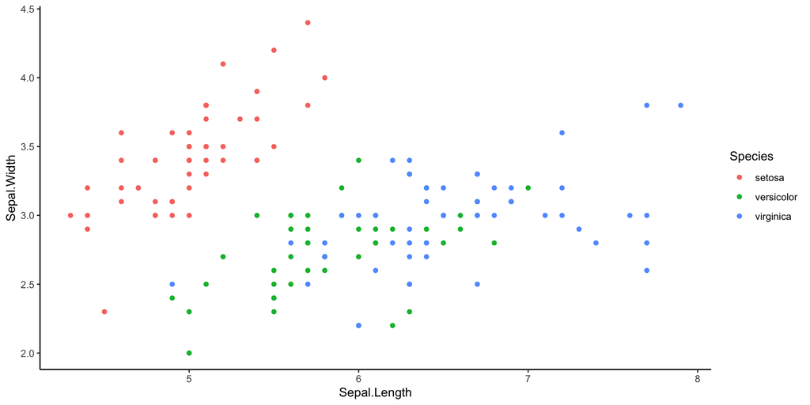

```r
library(ggplot2)
# plot a very nice plot based on iris dataset
ggplot(iris, aes(x = Sepal.Length, y = Sepal.Width, color = Species)) +
    geom_point() +
    theme_classic()
```

## Code example 3

In this example we use the `#| output-location: column` execution option to automatically place the output in a column next to the code. As execution options are not shown in Quartz slides, you will need to view the `.qmd` source of this slide to see how it is implemented.

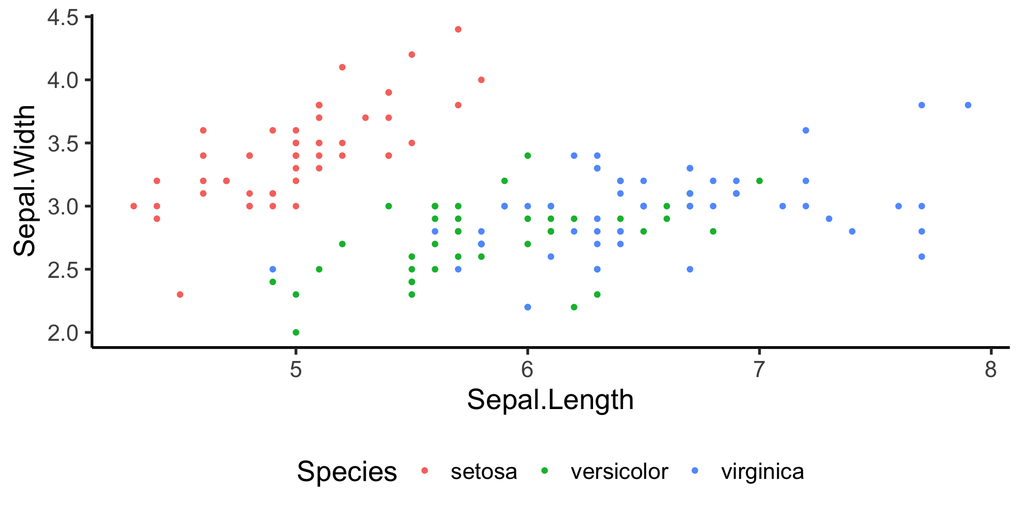

```r
ggplot(iris, aes(x = Sepal.Length,
       y = Sepal.Width, color = Species)) +
    geom_point() +
    theme_classic(base_size = 20) +
    theme(legend.position = "bottom")
```

## Equations

Equations are based on [**LaTeX**](https://www.latex-project.org/) and powered by [**MathJax**](https://quarto.org/docs/authoring/math.html).

### Inline equations

Inline equations are surrounded by `$`. For example, the equation $y = \beta_0 + \beta_1 x + \epsilon$ is a linear regression model.

### Display equations

Display equations are surrounded by `$$`. For example, one way to display the equation for a [Fourier series](https://en.wikipedia.org/wiki/Fourier_series) is:

$$f(x) = \frac{a_0}{2} + \sum_{n=1}^{\infty} \left[ a_n \cos \left( \frac{2 \pi n x}{L} \right) + b_n \sin \left( \frac{2 \pi n x}{L} \right) \right]$$

## Callout blocks

**Note**

Callout blocks are a way to draw attention to important points. They are rendered in a larger font size in this template.

**Tip**

Read more about callout blocks in the [Quarto documentation](https://quarto.org/docs/authoring/callouts.html).

# Thanks!

This presentation is based on the [SOLES Quarto reveal.js template](https://github.com/usyd-soles-edu/soles-revealjs) and is licensed under a [Creative Commons Attribution 4.0 International License](http://creativecommons.org/licenses/by/4.0/).